# Lecture Week 04: Distributions

# 1 Overview

This week, we will introduce number distributions with particular focus on the **Normal Distribution**.

- We will go over how to describe normal distributions
- The standard normal distribution
- How to make any normal distribution a standard normal distribution.
- We will also discuss why many statistics assume a normal distribution, and why this is often appropriate.
- We will briefly discuss transformations to make a log-normal distribution normal.
- Other distributions will be briefly introduced if time allows

# 2 Setup

### 2.0.1 Libraries

```r
library(tidyverse)
```

### 2.0.2 Data

- No data is needed for this lecture

# 3 Lecture Outline

## 3.1 Introduce number distributions

- Why should we care about how numbers are distributed?
  - So we can know what’s an expected or unexpected observation
- For example, what do you think the average height of a human is?
  - Write on board
- I’m sure there will be variation in answers, but I bet no one said 4 or 7 feet
  - Meeting someone of this height may not be shocking, but it’s rare enough that it would probably be memorable
  - Likewise, I’ll bet no one has ever met anyone who was 10 feet tall

## 3.2 What is the normal distribution?

- The normal distribution is also called a Gaussian distribution and commonly called the “bell curve”
- The density plot for a Normal distribution looks like this:

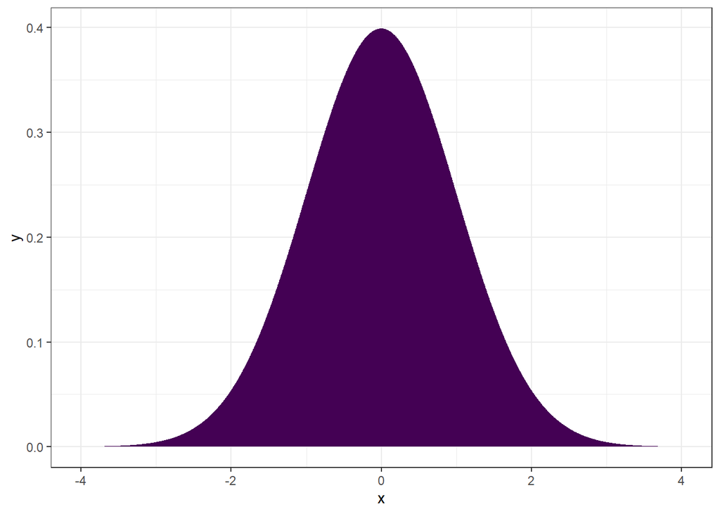

- The value, x, has a density, y
  - Unimodal
    - One “peak”
  - Values in the middle (i.e., x = 0) have a high density, meaning they are likely to be observed
  - Values at the ends, i.e., -4, 4, have a low density, meaning they are unlikely to be observed.
- Describe it with $\mu$ (location) and $\sigma$ (spread)
  - Symmetric distribution centered at $\mu$
  - The width of the curve is described with $\sigma$
- Mathematically we write:
  - $\Large X \sim \text{Normal} (\mu,~ \sigma)$
- And say
  - “X is a random normal variable with mean mu and standard deviation sigma”
- Note that “real” data will not be perfectly normal
- Here is an example of the density of 100 observations from a normal distribution with $\mu = 5.5$ and $\sigma = 1.2$

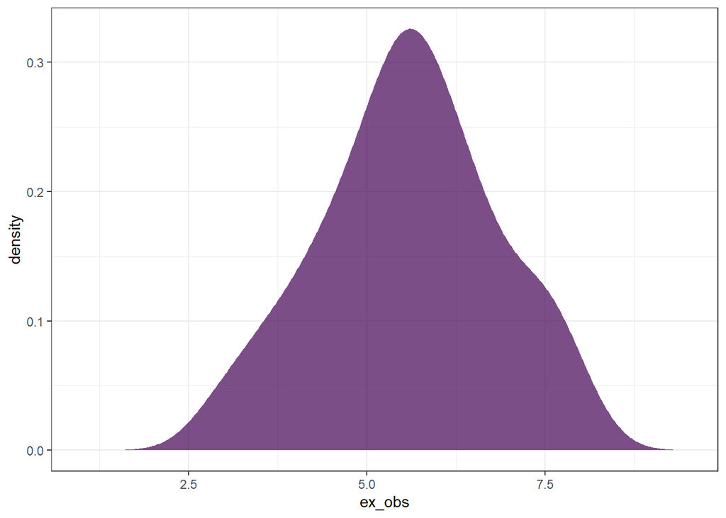

```r
set.seed(21)
ex_obs <- rnorm(100, mean = 5.5, sd = 1.2)
ex_obs |>
  as_tibble() |>
  ggplot(aes(x = ex_obs,
             fill = "fill")) +
  stat_density(alpha = 0.7) +
  theme_bw() +
  scale_fill_viridis_d() +
  xlim(c(1, 9.5)) +
  theme(legend.position = "none")
```

- Note that it is “lumpy”, Not perfectly symmetrical, etc.
- We’re usually looking to ensure that it looks *generally* normal.

## 3.3 Compare Normal Distributions

- Different Locations but same spread

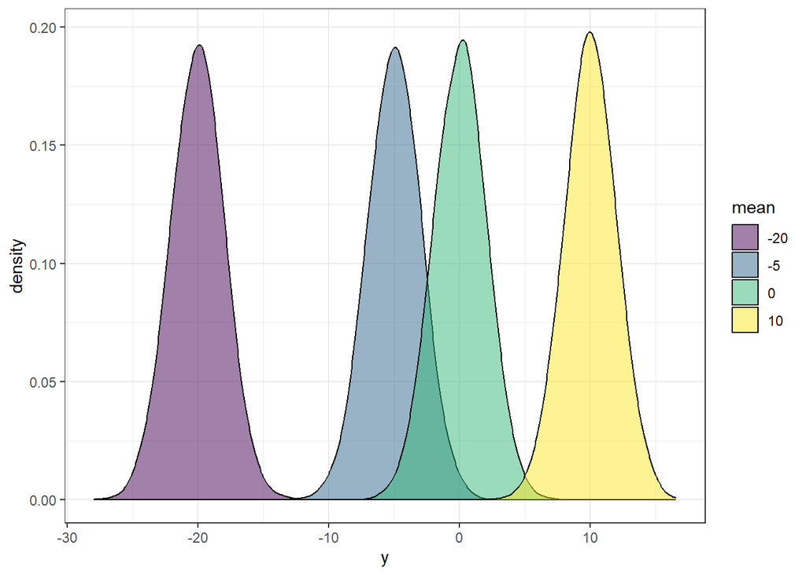

- Same location but different spread

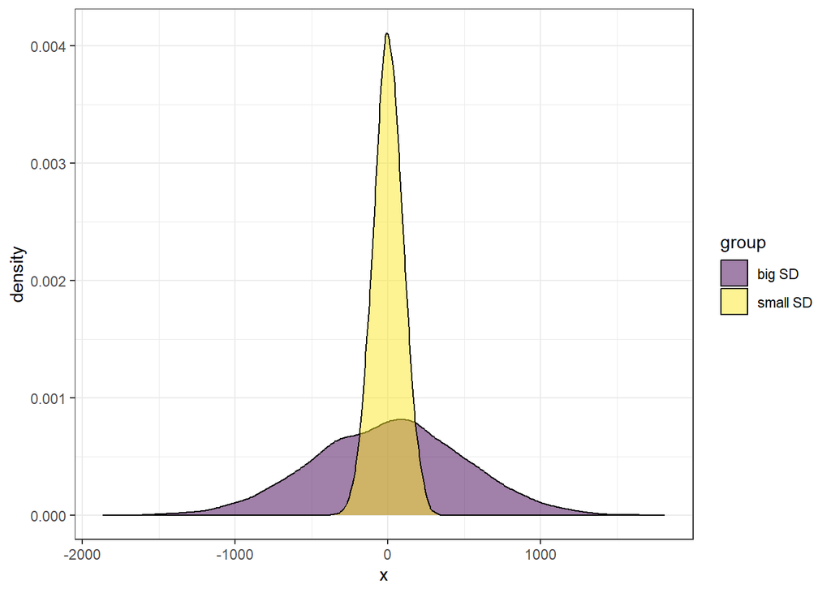

```r
set.seed(3987)
x1 <- rnorm(10000, 0, 500)
x2 <- rnorm(10000, mean = 0, sd = 100)
df <- data.frame(x = c(x1, x2),
                 group = rep(c("big SD", "small SD"), each = 10000))

ggplot(df, aes(x = x,
               group = group,
               fill = group)) +
  geom_density(alpha = 0.5) +
  theme_bw() +
  scale_fill_viridis_d()
```

## 3.4 The Empirical Rule

- By knowing the mean and SD, we have a good idea of where the majority of the data falls
- $\mu \pm \sigma = 68\%$ of the data
- $\mu \pm 2\sigma = 95\%$ of the data
- $\mu \pm 3\sigma = 99.7\%$ of the data

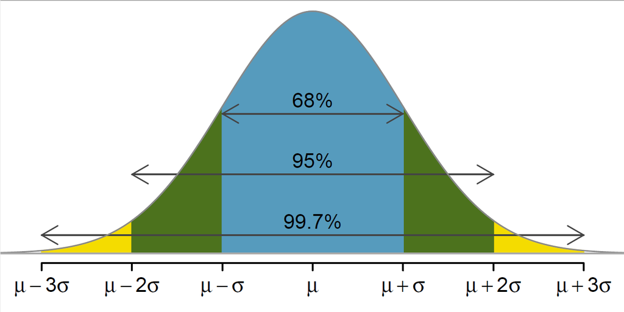

The Empirical Rule (image credit Open Intro Statistics).

- When working with normal distribution problems:
  - Sketch a bell curve
  - Put the mean value in the middle
  - Put the mean $\pm$ 1 or 2 SD on the figure
  - Draw a line or mark where the value you’re thinking about is.
- For example, let’s say we have a variable $y$, which has:
  - $\Large y \sim \text{Normal} (\mu = 10,~ \sigma = 2)$
- The curve is centered at our mean of 10 (tallest part of the “bell”)
- Add a few marks indicating 1 and 2 standard deviations away from the mean:
  - $10 \pm 2 = (8, 12)$
  - $10 \pm 2*2 = (6, 14)$
- Sketch the overall distribution

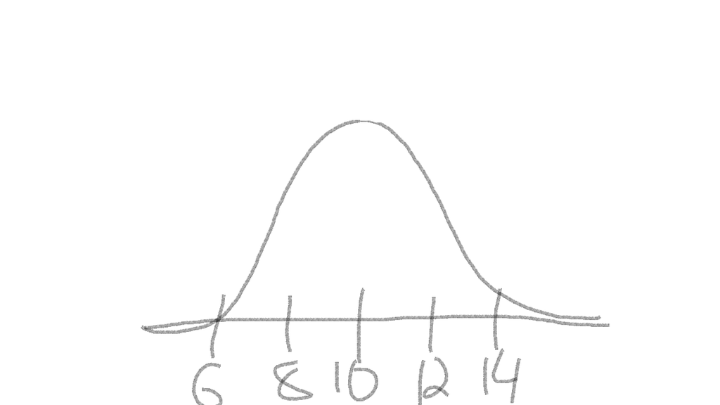

Sketch or a normal distribution.

- Then, you can quickly sketch where a give observation would fall on the distribution.
- For example, if we had an observation of 9.7 and 13, I would quickly add them to the sketch:

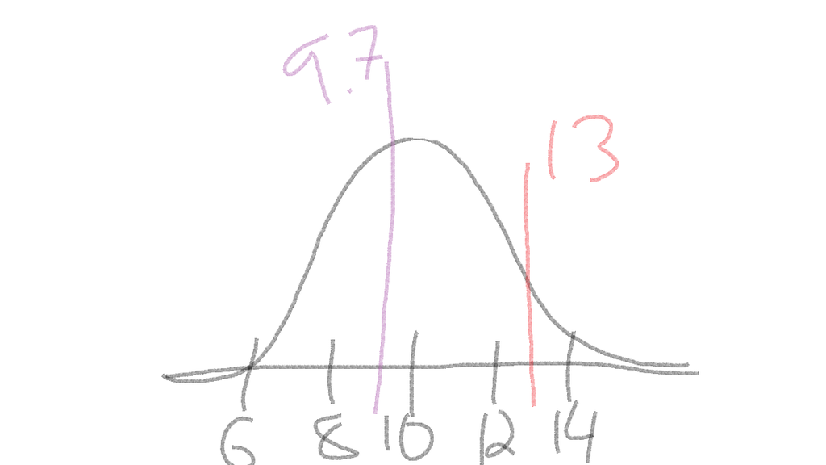

Figure 5. Sketch with observations.

- So, 9.7 is a reasonable observation
- 13 is not common, but maybe not incredibly rare

## 3.5 Sketch Activity

- When a gallon of gas is burned, the amount of CO<sub>2</sub> that is released can be described with a normal distribution with a mean of 8,800 and a SD of 500 grams.
  1. Describe this distribution with a mathematical equation
  2. Sketch this distribution and include the mean, and values which are $\pm$ 1 and 2 SDs
  3. What is the likelihood of observing 9000 g of CO<sub>2</sub> from one gallon of gas?
  4. What about observing anything over 10,000 g of CO<sub>2</sub>?

## 3.6 Working with Normal distributions in R

- Sketching out a normal distribution is a great “gut check” when answering questions about normal distributions.
- We can also use R to get exact answers for probability of observing some values.
- Let’s look at an empirical distribution for CO<sub>2</sub> described above

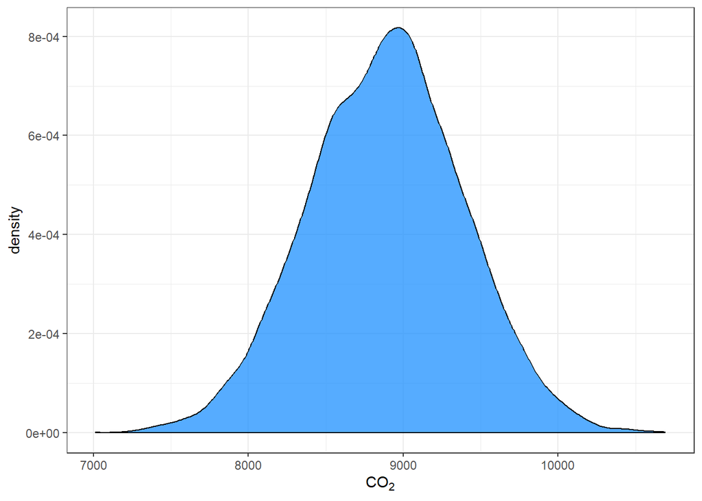

**Note to instructor**

#### 3.6.0.1 Draw multiple copies of the density plot on board

- Annotate one at a time to highlight concepts
- i.e., exact probabilities
- “up to” probabilities
- Quantiles
- etc.

### 3.6.1 Observing an exact number

- Now, let’s look again at our example above of observing 9000g of CO<sub>2</sub>

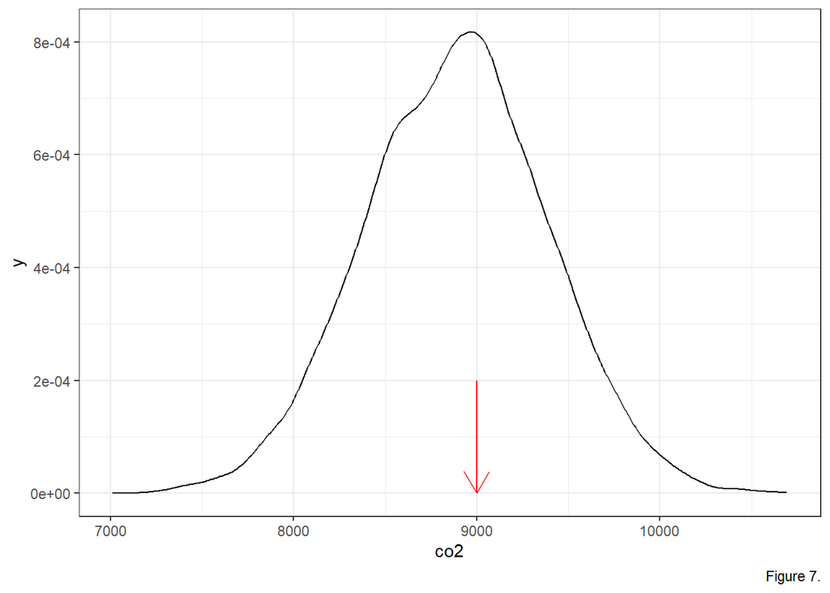

```r
ggplot(co2_df, aes(x)) +
  geom_density() +
  labs(x = "co2",
       caption = "Figure 7.") +
  theme_bw() +
  annotate("segment",
           x = 9000,
           xend = 9000,
           y = 2e-04,
           yend = 0,
           color = "red",
           arrow = arrow(length = unit(0.05, "npc")))
```

- To do this, we can use the `dnorm()` function
  - “d” is for density
  - It tells us the probability of observing an number exactly
  - To use the `_norm()` functions (more functions coming up) we need to specify the mean and sd values
    - If we don’t it will assume `mean=0` and `sd=1`
    - This is called the “special normal” distribution which we will discuss below.

```r
dnorm(9000, mean = 8800, sd = 500)
```

```
[1] 0.0007365403
```

- That’s a astonishingly small probability!
- Any ideas what happened here?
- This is the probability of observing *EXACTLY* 9000 g
- The probability of observing any number exactly is small
- Even for the mean value, which should be the most common and has the highest single probability of being observed:

```r
dnorm(8800, mean = 8800, sd = 500)
```

```
[1] 0.0007978846
```

### 3.6.2 Observing *up to* some value

- What we usually want to know is the probability of observing *up to* some value.

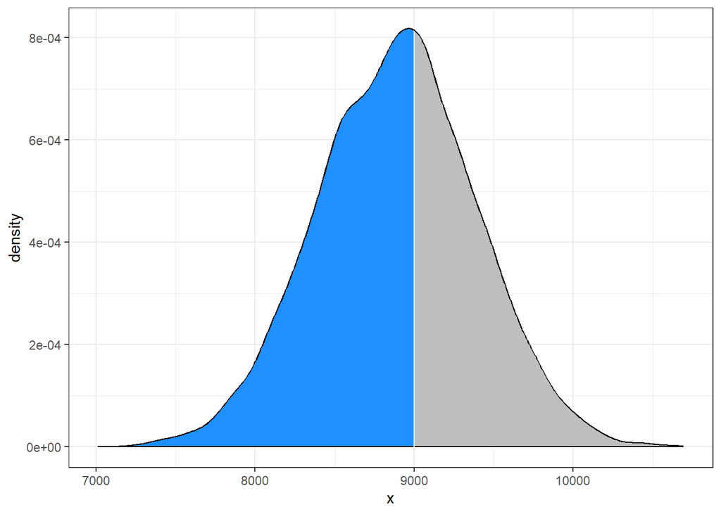

- For that, we use `pnorm()`

```r
pnorm(9000, mean = 8800, sd = 500)
```

```
[1] 0.6554217
```

```r
pnorm(8800, mean = 8800, sd = 500)
```

```
[1] 0.5
```

- That should make more sense
- We have a ~65% probability of observing a value up to 9000g
- We have a 50% probability of observing 8800 g, which is in the middle
- What about the probability of observing anything greater than 9000g?
- Density probabilities sum to 1, so we can calculate this in one of two ways
  - We can subtract the probability we calculated above from 1
  - Or, we can set an optional argument in the `pnorm()` function

```r
1 - pnorm(9000, mean = 8800, sd = 500)
```

```
[1] 0.3445783
```

```r
pnorm(9000, mean = 8800, sd = 500, lower.tail = FALSE)
```

```
[1] 0.3445783
```

- Both give us the same answer
  - Either one is fine
  - I’d recommend memorizing whichever one makes sense and just use that.
  - I tend to use the `lower.tail` argument so I don’t have to remember to do the subtraction, but whatever works for you is fine.

### 3.6.3 Observing a number between two values

- Let’s say we want to know the probability of observing a value between 9000 and 10,000g of CO<sub>2</sub>

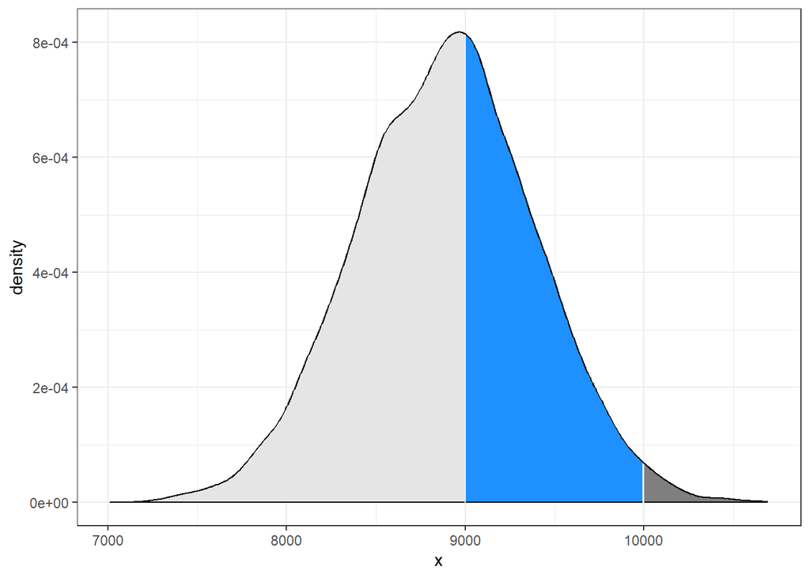

- For this, we first calculate the probability of the larger number, then subtract the probability of the smaller number:

```r
pnorm(10000, mean = 8800, sd = 500) - pnorm(9000, mean = 8800, sd = 500)
```

```
[1] 0.3363807
```

### 3.6.4 What value is at a given percentile?

- It can also be useful to know what value separates given percentiles (AKA quantiles) of our data.
- For example, what value of CO<sub>2</sub> marks the 10% percentile? What about the 95%?
- For this, we use `qnorm()`

```r
qnorm(0.1, 8800, 500)
```

```
[1] 8159.224
```

```r
qnorm(0.95, 8800, 500)
```

```
[1] 9622.427
```

- so a value of ~8160g marks the 10% percentile, while a value of ~9622 is at the 95% percentile

### 3.6.5 Draw a random observation from a sample

- Finally, we can use `rnorm()` to draw random number(s) from a given normal distribution
  - The first argument, `n` , tells R how many observations to draw
  - I will also set the seed so that it is reproducible and we all get the same values

```r
set.seed(943)
# one observation
rnorm(1, mean = 10, sd = 2)
```

```
[1] 9.207663
```

```r
# 5 observations
rnorm(5, mean = 10, sd = 2)
```

```
[1]  8.472591  8.175600 10.998759 10.098632 10.798486
```

## 3.7 Standard-Normal Distribution

- The standard normal distribution is a special case where $\mu = 0$ and $\sigma = 1$
- Sometimes called the Z distribution

| Empirical rule percentage | Min value | Max value |
| --- | --- | --- |
| 68% | -1 | 1 |
| 95% | -2 | 2 |
| 99.7% | -3 | 3 |

## 3.8 Z-scores

- One cool thing about normal distributions is that we can turn any of them into a standard normal dsitribution
- We do this by giving every observation a Z-score with the following formula

$\Large Z = \frac{x_{i} - \hat\mu} {\hat\sigma}$

- Where $Z$ is the standardized score
- $x_i$ is the individual observation
- $\hat\mu$ is mean estimated from the sample
- $\hat\sigma$ is SD estimated from the sample
- Calculate z-scores from a random sample

```r
# draw 5 random observations
set.seed(2112)
x_samp <- rnorm(5, mean = 10, sd = 2)
# look at them
x_samp
```

```
[1] 11.848674  9.384994  8.747174  8.754401 11.161425
```

```r
# calculate z-score
(x_samp - mean(x_samp)) / sd(x_samp)
```

```
[1]  1.3005631 -0.4135018 -0.8572551 -0.8522266  0.8224205
```

- in this case, all observations are within 2 SDs, and most (4/5) are within 1 SD.

### 3.8.1 Comparing Z-scores

$Z_{A} = \frac{x_{A} - \mu_{SAT}}{\sigma_{SAT}} = \frac{1800-1500}{300} = 1$

$Z_{B} = \frac{x_{B} - \mu_{ACT}}{\sigma_{ACT}} = \frac{24 - 21}{5} = 0.6$

- Student A has a z-score of 1, which is higher than the z-score for student B of 0.6.
- So student A was further away from the mean then student B and because the value was positive it’s closer to the right side of the distribution.
- In other words, student A performed better than student B.

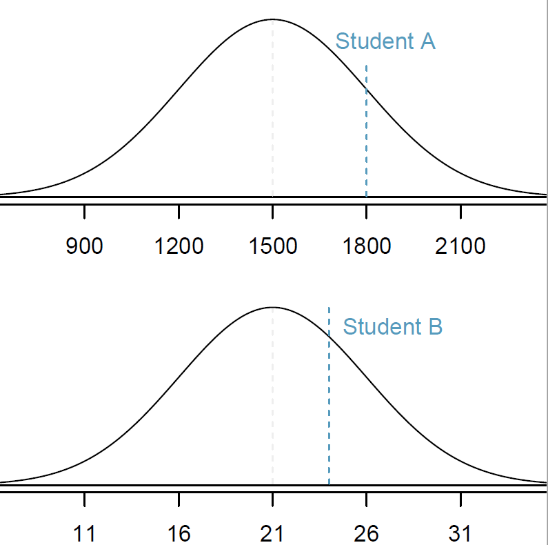

SAT and ACT Scores for student A and B. (image credit Open Intro Statistics)

## 3.9 Why are normal distributions normal?

- Gaussian distributions are called “normal” because they are frequently observed in many natural phenomena
  - Height, weight, measurement errors, blood pressure, shoe size, retirement age of professional football players…
- When we go out and measure things, a common, typical, usual, etc. pattern is that the measurements take on a Gaussian distribution with:
  - Many measurements are close to one value (the mean)
- Many processes can lead to normal distributions

### 3.9.1 Binary addition processes leading to normal distributions

- A binary process is something which has one of two outcomes
  - i.e., a coin toss results in heads or tails
  - An individual either survives or dies, reproduces or doesn’t reproduce, etc.
- When we add up these binary processes, they often lead to Gaussian distributions
- Let’s sample in R to demonstrate this

```r
set.seed(579)
sample(x = c(-1, 1), size = 1)
```

```
[1] -1
```

- The `sample` function chooses from the values in x (i.e., either a 1 or a -1)
- The size is the number of samples to take
- If we run it multiple times we can see that we get about half 1’s and half -1’s
- We can increase this by changing the size argument
  - Add the `replace = TRUE` argument so that it doesn’t run out of options

```r
sample(x = c(-1, 1), size = 10, replace = TRUE)
```

```
 [1]  1  1  1  1 -1 -1 -1  1 -1  1
```

- We can take it one step further by adding these together by wrapping the whole thing in a `sum()` argument

```r
# set some seed here
sum(sample(x = c(-1, 1), size = 10, replace = TRUE))
```

```
[1] -2
```

- Everyone set a unique seed and run the above code and tell me your result

**Write results on board**

- Make a number line and add the results
- What does it look like?
- Normal?
- Let’s increase our simulation one more way to show how this would look if we continued to sample

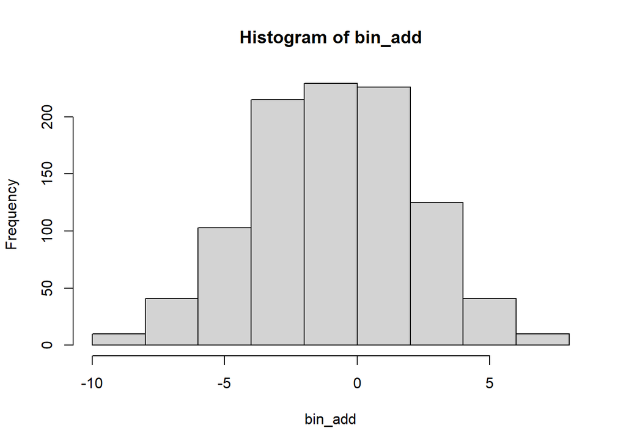

```r
set.seed(33)
bin_add <- replicate(1000,
                     sum(
                       sample(x = c(-1, 1), size = 10, replace = TRUE)))
hist(bin_add)
```

- Looks pretty normal to me
- This happens because of all the possiblities, there are very few ways to get -10 or 10
  - i.e., every result in our 10 “coin flips” would have to be either Heads or Tails
- There are a lot of ways to get a 0
  - One average, half our flips will be -1 and half will be 1, so the sum = 0
- But how realistic is this?
- An often cited example is human height
- Human height is determined by a number of factors
  - Numerous genes, many with only 2 alleles
  - Mother’s health before, during, and after pregnancy
  - Nutrition throughout growth
  - Environmental factors
- Many of these events are independent (though not all) and may of them can be simplified as having one of two possible outcomes
- Of all the possibilities, it is rare to have all these independent events result in “short” or “tall” outcomes
- At the population level, the few extreme examples (i.e., very tall or very short) tend to “cancel each other out”
- Resulting in most people being close to the average

### 3.9.2 Multiplicative processes leading to normal distributions

- Quickly, we can show a similar process when many processes which have a small effect are multiplied together
- In this case, think of all those genetic markers which are related to height.
  - They are not truly “tall” and “short” alleles
  - In reality, they probably all interact with one another, such that each contributes a percentage to making a person shorter or taller
- We can simulate this by sampling from a uniform distribution and adding it to 1

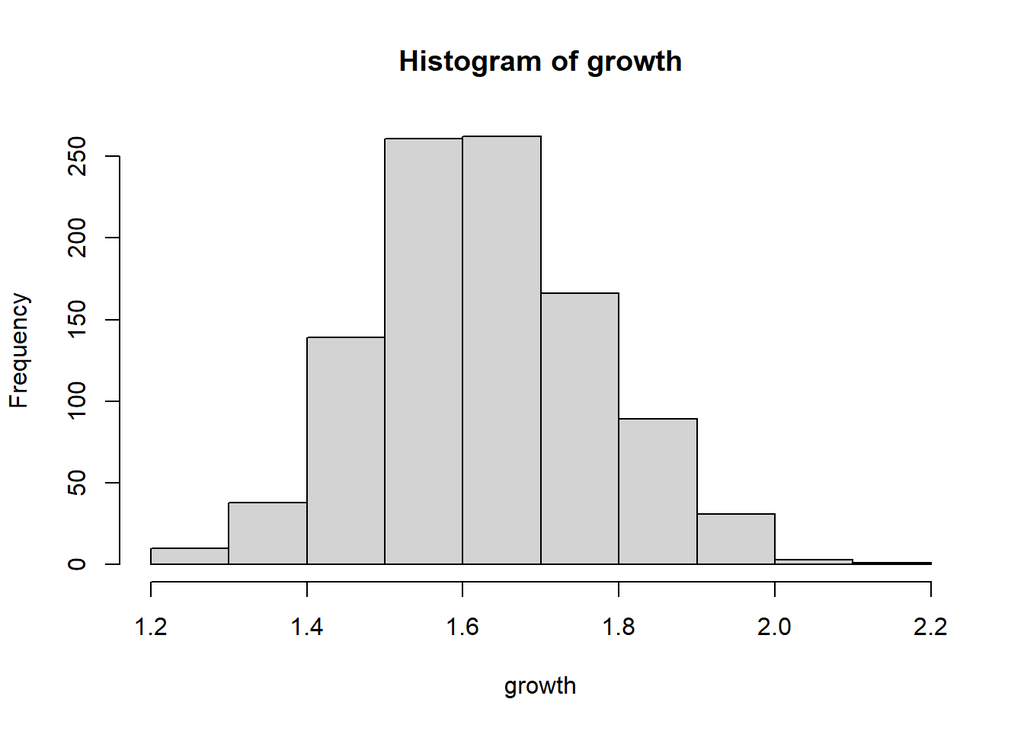

```r
set.seed(444)
growth <- replicate(1000,
                    prod(1 + runif(10, min = 0, max = 0.1)))
hist(growth)
```

## 3.10 Log-normal Distribution

- Another common distribution in nature is the log-normal distribution
- This is a distribution which has an extremely long right tail when looking at the raw values
- But it looks normal after performing a log transformation

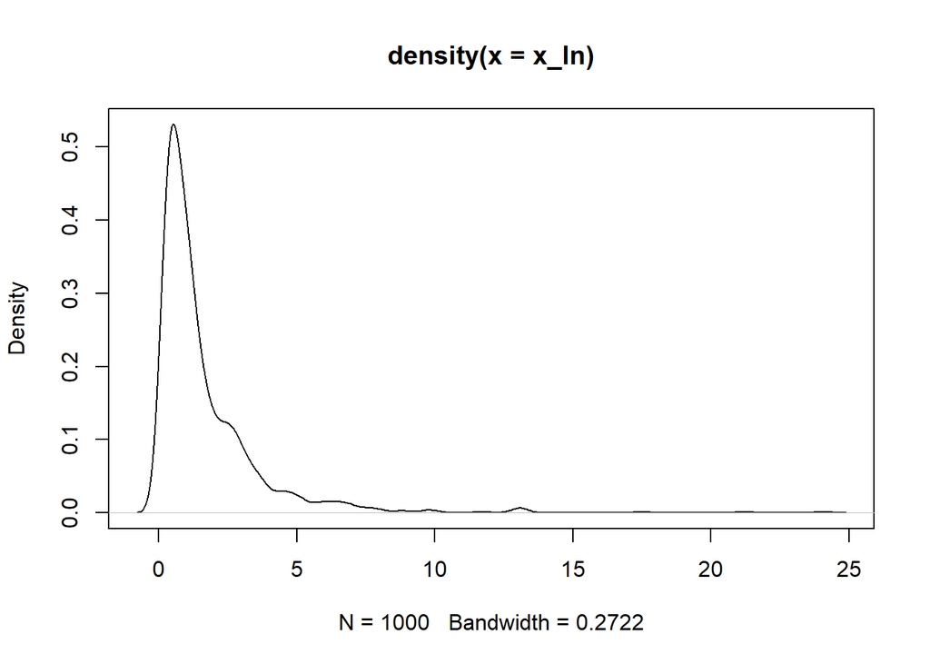

```r
set.seed(987) # for reproducibility
x_ln <- rlnorm(1000) # sample 1000 observations from a log-normal distribution

# plot the values
plot(density(x_ln))
```

- We can see that this is a highly skewed data set
  - lots of observations on the left side (peak)
  - very few observations of really large numbers (right side).

### 3.10.1 Log transformation

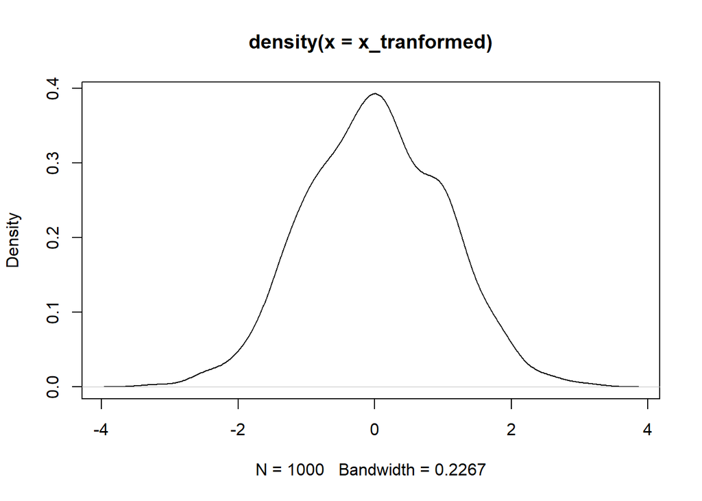

```r
x_tranformed <- log(x_ln)

plot(density(x_tranformed))
```

- We can see now that the distribution is approximately normal.
- Note that this has been a standard method in statistical analyses for many years
- There are now modern approaches which are more appropriate
- We will use log-transformations in the next few weeks and learn the other techniques later
- We will discuss other transformations as they come up in class later.

## 3.11 Other Distributions

- There are many other distributions
- Some that we will look at in detail later include:
- Poisson
  - Discrete positive values
  - This is a “bound” distribution
    - Cannot be negative
  - usually a count
  - The mean and the variance are the same

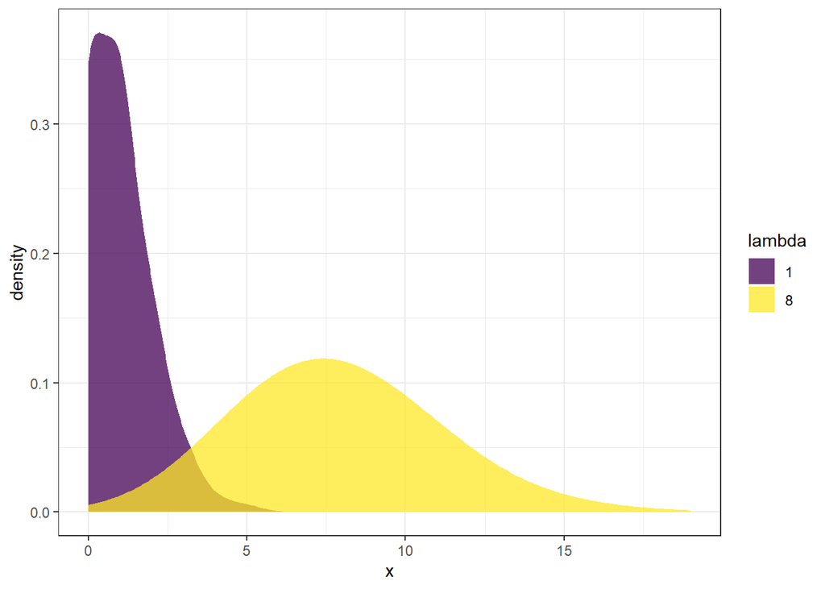

```r
set.seed(777)
x_pois1 <- rpois(1000, 1)
x_pois2 <- rpois(1000, 8)

tibble(x = c(x_pois1, x_pois2),
       lambda = factor(rep(c(1, 8), each = 1000))) |>
  ggplot(aes(x = x,
             group = lambda,
             fill = lambda)) +
  stat_density(alpha = 0.75,
               position = "identity",
               adjust = 3)+ # adjust to "blend out" discrete peaks
  scale_fill_viridis_d() +
  theme_bw()
```

- Negative Binomial
  - Similar to Poisson
  - Except the mean and variance are *not* the same
  - Usually has more 0’s than “would be expected”

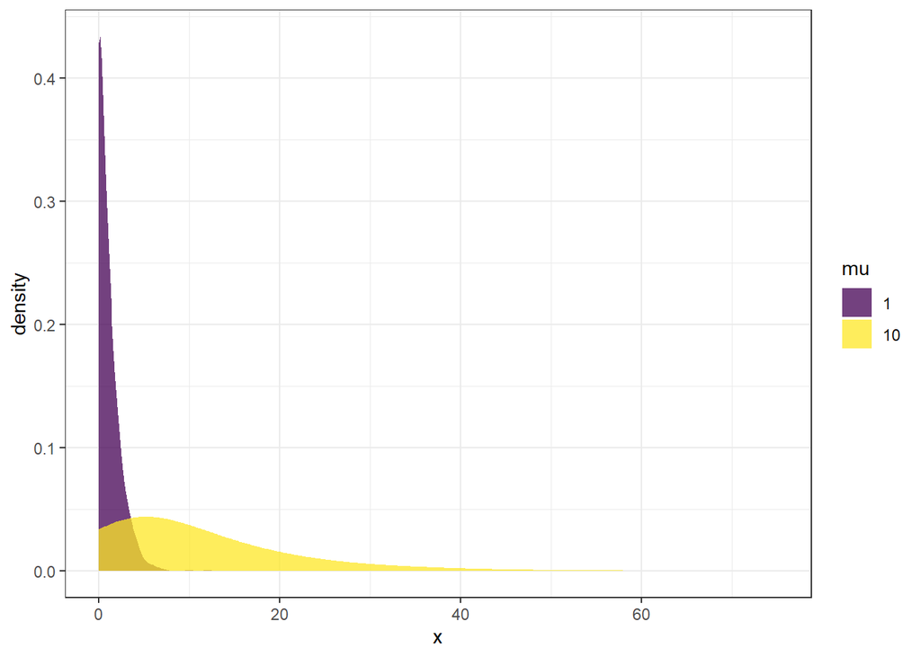

```r
set.seed(777)
x_nb1 <- rnbinom(n = 1000, 1, mu = 1)
x_nb2 <- rnbinom(n = 1000, 1, mu = 10)

tibble(x = c(x_nb1, x_nb2),
       mu = factor(rep(c(1, 10), each = 1000))) |>
  ggplot(aes(x = x,
             group = mu,
             fill = mu)) +
  stat_density(alpha = 0.75,
               position = "identity",
               adjust = 3)+ # adjust to "blend out" discrete peaks
  scale_fill_viridis_d() +
  theme_bw()
```

- Binomial
  - Response is one of two possibilities
  - This is different than binary processes above
    - Above, many binary events occur leading to some result
    - Here, the response is binary
  - Generally, looking at the *proportion* of results which are a 0 or 1
    - This is a bound distribution where $0 \le x \le 1$

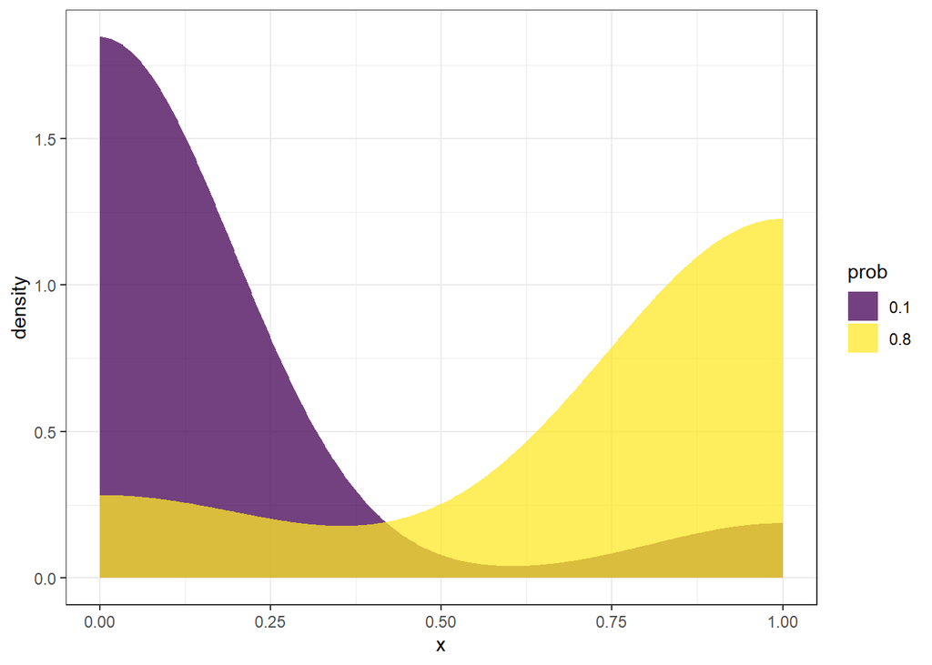

```r
set.seed(777)
x_nb1 <- rbinom(n = 1000, 1, 0.1)
x_nb2 <- rbinom(n = 1000, 1, 0.8)

tibble(x = c(x_nb1, x_nb2),
       prob = factor(rep(c(0.1, 0.8), each = 1000))) |>
  ggplot(aes(x = x,
             group = prob,
             fill = prob)) +
  stat_density(alpha = 0.75,
               position = "identity",
               adjust = 3)+ # adjust to "blend out" discrete peaks
  scale_fill_viridis_d() +
  theme_bw()
```

## 3.12 Other transformations

- Proportion data - arcsin-square root
  - example `x_transformed <- asin(sqrt(x))`
  - Takes proportion data (from 0-1) and “normalizes” it
  - Can be hard to interpret transformed values
- Right skewed data - Log, log<sub>10</sub>, amd square root transformation
  - Reduce right skewness
    - Makes big values smaller
  - Stabilize variance
- [Other examples of non-normal data and transformations](https://www.datanovia.com/en/lessons/transform-data-to-normal-distribution-in-r/)
  - positive and negative skew

## 3.13 Alternative statistical methods when working with non-normal data

- As mentioned above, transformations have been common in statistical analyses
- We will go over them as needed in class
- Generally, better options now exist and we will go over a few of them later in the semester

# 4 Summary

- The normal distribution is ubiquitous in the natural world
- It can be formed from many different processes
  - i.e., binary, multiplicative
- Central limit theorem
- It can be described with $\mu$ (the location of the “peak”) and $\sigma$ (a measure of how “wide” it is).
- There are many `_norm()` functions in R which can tell us the:
  - Probability of observing an exact number `dnorm()`
  - Probability of observing up to a given number `pnorm()`
  - What quantile a given number is in a distribution `qnorm()`
  - We can also generate random observations from a normal distribution `rnorm()`
- The default arguments for these functions has `mean = 0` and `sd = 1`, i.e., standard normal
- The Standard normal distribution is a special case where $\mu = 0$ and $\sigma = 1$
- Any normal distribution can be created with the Z-transformation:
  - $\Large z = \frac{x_{i} - \mu} {\sigma}$
- Z-scores can be compared even when the original data were on different scales
- A log-normal distribution is a non-normal distribution which takes on attributes of a normal distribution after it has been log-transformed
- Other transformations exist for different underlying distributions